# The Approach

Formula 1 Driver Report

Peter Loftstrand Elena Zaytseva Xi Dou John Holsapple

Business Decisions

Our client, an F1 hedge fund, wants to determine the performance measures that best dictate an F1 championship. This client has historical data for 80 drivers that are widely considered the best drivers of all time.

The Data

Our data is collected from http://f1-facts.com/stats/drivers/fastest-laps. The data represents drivers from the 1950’s until today.

The data set includes the following parameters: 1- Points- The number of points earned in F1 race. 2- Championships- The number of F1 championships 3- Victories- The number of wins 4- Poles- Start the race in first, because of qualification time 5- Fastest Lap- The fastest lap in a race 6- Podium- One of top three racers 7- Entries- Number of attempted match entries 8- Qualifications- Number of matches qualified for 9- Classified- Points earned in incomplete races 10- CP- Comparsion points determined by: Qualified better/worse than team-mate(s): +1/-1 Classified better/worse than team-mate(s): +2/-2 Better/slower fastest lap than team-mate(s): +1/-1

We will see some descriptive statistics of the data later, when we get into statistical analysis.

### The Approach

Intuitively it may seem that the data above capture two fundamental abilities that affect the success of students in their management careers:

1. Basic intelligence
2. Team and Leadership skills.

The school may be interested for example in picking students who score high on these two areas. In this case, of course the admissions commitee in theory could just ask the applicants two questions:

1. “How intelligent are you?”
2. “How strong are your team and leadership skills?”

As you can imagine, asking these questions would not only make the admissions interviewers look naive, but would also lead to very noisy and misleading answers: of course everyone will just answer both questions with the highest mark. So instead of asking these “naive” questions, the school is using *raw attributes/data* like the ones above, which can also be gathered easier. The idea then is to see how this data can be “translated” in meaningful derived attributes that, for example, could capture the “equivalent answers” one could get if one were to ask directly the two naive questions above - or possibly other such “complex”“ questions.

> Factor analysis is a statistical approach for finding a few "hidden” derived attributes in data by combining together groups of the original raw attributes in such a way that the least information in the original data is lost - in a statistical sense. It is part of a general class of statistical methodologies used to do what is often called “dimensionality reduction”.

> Data reduction is a very useful step in helping us interpret the data and make decisions.

Like for our example, theory may suggest that there are really one or two basic factors (like intelligence and leadership skills) that lead to success in a management career. The various attributes are really different manifestations of these basic factors. But maybe there are other hidden derived variables (factors) in the data we have: instead of us manually combining raw attributes into meaningful derived ones, which not only is diffucult with many data but also dangerous as we impose our biases, let's get *factor analysis* to do the job for us - and use our intuition and judgment in the process.

Let's now see **a** process for using factor analysis in order to create derived attributes, the goal of this report.

### A Process for Dimensionality Reduction

> It is important to remember that Data Analytics Projects require a delicate balance between experimentation, intuition, but also following (once a while) a process to avoid getting fooled by randomness and “finding results and patterns” that are mainly driven by our own biases and not by the facts/data themselves.

There is *not one* process for factor analysis. However, we have to start somewhere, so we will use the following process:

#### Factor Analysis in 6 steps

1. Confirm the data in metric
2. Decide whether to scale or standardize the data
3. Check the correlation matrix to see if Factor Analysis makes sense
4. Develop a scree plot and decide on the number of factors to be derived
5. Interpret the factors (consider factor rotations - technical but useful)
6. Save factor scores for subsequent analyses

Let's follow these steps.

#### Step 1: Confirm the data are metric

Steps 1-3 are about specific descriptive characteristics of the data. In particular, the methods we consider in this note require that the data are *metric* (step 1): this means not only that all data are numbers, but also that the numbers have an actual numerical meaning, that is 1 is less than 2 which is less than 3 etc. If we have other types of data (e.g. gender, categories that are not comparable, etc), there are other methods to use. However, for now we will only consider a specific method, which we will also mis-use for non-numeric data for simplicity.

> Note that one should spend a lot of time getting a feeling of the data based on simple summary statistics and visualizations: good data analytics require that we understand our data very well.

#### Step 2: Decide whether to scale or standardize the data

```r
ProjectDatafactor_scaled=apply(ProjectDataFactor,2, function(r) {if (sd(r)!=0) res=(r-mean(r))/sd(r) else res=0*r; res})
```

While this is typically a necessary step, one has to always do it with care: some times you may want your analytics findings to be driven mainly by a few attributes that take large values; other times having attributes with different scales may imply something about those attributes. For example, when students rate their schools on various factors on a 1-7 scale, if the variability is minimal on a certain variable (e.g. satisfaction about the IT infrastructure of the school) but very high on another one (e.g. satisfaction with job placement), then standardization will reduce the real big differences in placement satisfaction and magnify the small differences in IT infrastructure satisfaction. In many such cases one may choose to skip step 2 for some of the raw attributes. Hence standardization is not a necessary data transformation step, and you should use it judiciously.

#### Step 3: Check correlation matrix to see if Factor Analysis makes sense

The type of dimensionality reduction methods we will use here “groups together raw attributes that are highly correlated”. Other methods (there are many!) use different criteria to create derived variables. For this to be feasible, it is necessary that the original raw attributes do have large enough correlations (e.g. more than 0.5 in absolute value, or simply statistically significant). It is therefore useful to see the correlation matrix of the original attributes - something that one should anyway always do in order to develop a better understanding of the data.

This is the correlation matrix of the 10 original variable we use for factor analysis (Note: this would be the same for the standardized ones if the standardization is done as above; there is a mathematical reason for this that we will not explore - you could confirm it yourself):

|  | point | Champion | victories | poles | Fastest lap | podium | entries | qualification | classified | CP |
| --- | --- | --- | --- | --- | --- | --- | --- | --- | --- | --- |
| point | 1.00 | 0.64 | 0.73 | 0.71 | 0.69 | 0.81 | 0.53 | 0.55 | 0.75 | 0.49 |
| Champion | 0.64 | 1.00 | 0.81 | 0.81 | 0.73 | 0.69 | 0.31 | 0.32 | 0.41 | 0.56 |
| victories | 0.73 | 0.81 | 1.00 | 0.92 | 0.92 | 0.92 | 0.44 | 0.44 | 0.54 | 0.61 |
| poles | 0.71 | 0.81 | 0.92 | 1.00 | 0.84 | 0.85 | 0.41 | 0.42 | 0.49 | 0.54 |
| Fastest lap | 0.69 | 0.73 | 0.92 | 0.84 | 1.00 | 0.91 | 0.53 | 0.53 | 0.60 | 0.49 |
| podium | 0.81 | 0.69 | 0.92 | 0.85 | 0.91 | 1.00 | 0.63 | 0.63 | 0.72 | 0.54 |
| entries | 0.53 | 0.31 | 0.44 | 0.41 | 0.53 | 0.63 | 1.00 | 1.00 | 0.89 | 0.22 |
| qualification | 0.55 | 0.32 | 0.44 | 0.42 | 0.53 | 0.63 | 1.00 | 1.00 | 0.91 | 0.23 |
| classified | 0.75 | 0.41 | 0.54 | 0.49 | 0.60 | 0.72 | 0.89 | 0.91 | 1.00 | 0.31 |
| CP | 0.49 | 0.56 | 0.61 | 0.54 | 0.49 | 0.54 | 0.22 | 0.23 | 0.31 | 1.00 |

Let's now see what factor analysis suggests as factors.

#### Step 4. Develop a scree plot and decide on the number of factors to be derived

While there are as many (and for other methods, more) factors as the number of the original raw attributes, since our goal is to have a small(er) number of derived variables/factors, one question is whether we could use only a few of the components without losing much information. When this is feasible, we can say that the original raw attributes can be “compressed” to a few principal components/factors/derived variables. Note that this is not necessarily feasible - e.g. when the original raw attributes are uncorrelated and each one provides “trully different information from all the others” (in this case “different” means “uncorrelated”, but other statistical measures of “different” can be used, such as “statistically independent information”, leading to other well known dimensionality reduction methods such as *Independent Component Analysis (ICA)*, etc).

When using PCA, we have two measures of “how much of the information (variance in this case) in the original raw data is captured by any of the factors”:

a) the *percentage of variance explained*,

b) the *eigenvalue coresponding to the compontent*.

Note that the “first principal component” has the highest eigenvalue and captures most of the information (variance in this case) of the original raw data. As a rule of thumb, every component with eigenvalue more than 1 “has more information that the average original raw attribute”. Typically one uses only these factors, although what is also important to consider is “what total percentage of the variance in the original data is kept when one replaces the original data/attributes with the selected factors/components”.

> Two Statistical criteria to select the number of factors/derived variables when using PCA are: a) select components with corresponding eigenvalue larger than 1; b) Select the components with the highest eigenvalues “up to the component” for which the cumulative total variance explained is relatively large (e.g. more than 50%).

> A third rule of thumb to decide how many components to use is to consider only the factors up to the “elbow” of the scree plot.

#### 5. Interpret the factors (consider factor rotations - technical but useful)

In practice one would like to have derived variables that use only a few of the original raw attributes - while each new derived variable using different subsets of the original raw attributes. Unfortunately this is not necessarily always the case. However, there are mathematical methods, called “factor **rotations**”, which transform the estimated factors into new ones which capture exactly the same information from the raw data but use only few non-overlaping raw attributes. One such rotation often used in practice is called the varimax rotation - but others are also available.

How would you interpret the selected factors?

What Factor Loads “Look Good”? We often use three **Factor Technical Quality Criteria**:

1. For each factor (column) only a few loadings are large (in absolute value)
2. For each raw attribute (row) only a few loadings are large (in absolute value)
3. Any pair of factors (columns) should have different “patterns” of loading

#### Step 6. Save factor scores for subsequent analyses

Once we decided the factors to use (for now), we typically replace the original data with a new dataset where each observation (row) is now described not using the original raw attributes but using instead the selected factors/derived attributes. Afterall this was the goal of this analysis.

The way to represent our observations using the found derived attributes (factors/components) is to estimate for each observation (row) how it “scores” for each of the selected factor. These numbers are called **factor scores**. Effectively they are the “scores” the observation would take on the factor had we measured that factor directly instead of measuring the original raw attributes.

(**Note:** Sometimes for simplicity we represent each selected factor using one of the original raw attributes, typically the one on which the factor has the highest loading on. Although this is not statistically as accurate, it may help with the interpretation of subsequent analyses.)

Can you describe the observations using the new derived variables? How does each person perform for each of the selected factors?

> Data Analytics is an iterative process, therefore we may need to return to our original raw data at any point and select new raw attributes as well as new factors and derived variables.

**Till then…**

—- Next report input below here: —

Cluster Analysis and Segmentation

Let's fist use the **Hierarchial Clustering** method, as we do not know for now how many segments there are in our data. Hierarchical clustering is a method that also helps us visualise how the data may be clustering together. It generates a plot called the **Dendrogram** which is often helpful for visualization - but should be used with care. For example, in this case the dendrogram, using the euclidean distance metric from the earlier steps and the ward hierarchical clustering option (see below as well as help(hclust) in R for more information), is as follows:

[figure not shown]

[output not shown]

[output not shown]

[output not shown]

[output not shown]

[output not shown]

The chosen segments are described as per below:

Segment 1- “The Winners” The racers that fall into this segment have the highest probability of winning a championship.

Segment 2- “The Not Losers” The racers that fall into this segment have a low chance of winning a championship, but have/had some probability of moving into the first segment.

Segment 3- “Losers” The racers that fall into this segment have quite a low chance of winning a championship.

Segment 4- “Go to NASCAR” The racers that fall into this segment are not winners and should try racing in a box-car-derby.

We advise our client that drivers that fall into the first segment are more likely to win a championship; therefore, a better target for F1 hedge fund investment would more closely reflect the racers in this segment. Racers in segment three and four are not promising candidates for investment, because they have a low probability of winning a potential F1 race.

CLUSTER REPORT STARTS HERE

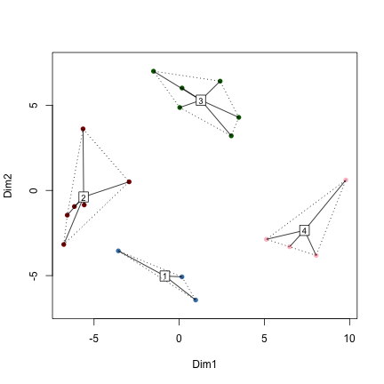

## What is this for?

In Data Analytics we often have very large data (many observations - “rows in a flat file”), which are however similar to each other hence we may want to organize them in a few clusters with similar observations within each cluster. For example, in the case of customer data, even though we may have data from millions of customers, these customers may only belong to a few segments: customers are similar within each segment but different across segments. We may often want to analyze each segment separately, as they may behave differently (e.g. different market segments may have different product preferences and behavioral patterns).

In such situations, to identify segments in the data one can use statistical techniques broadly called **Clustering** techniques. Based on how we define “similarities” and “differences” between data observations (e.g. customers or assets), which can also be defined mathematically using **distance metrics**, one can find different segmentation solutions. A key ingredient of clustering and segmentation is exactly the definition of these distance metrics (between observations), which need to be defined creatively based on contextual knowledge and not only using “black box” mathematical equations and techniques.

> Clustering techniques are used to group data/observations in a few segments so that data within any segment are similar while data across segments are different. Defining what we mean when we say “similar” or “different” observations is a key part of cluster analysis which often requires a lot of contextual knowledge and creativity beyond what statistical tools can provide.

Cluster analysis is used in a variety of applications. For example it can be used to identify consumer segments, or competitive sets of products, or groups of assets whose prices co-move, or for geo-demographic segmentation, etc. In general it is often necessary to split our data into segments and perform any subsequent analysis within each segment in order to develop (potentially more refined) segment-specific insights. This may be the case even if there are no intuitively “natural” segments in our data.

## Clustering and Segmentation using an Example

In this note we discuss a process for clustering and segmentation using a simple dataset that describes attitudes of people to shopping in a shopping mall. As this is a small dataset, one could also “manually” explore the data to find “visually” customer segments - which may be feasible for this small dataset, although clustering is in general a very difficult problem even when the data is very small.

Before reading further, do try to think what segments one could define using this example data. As always, you will see that even in this relatively simple case it is not as obvious what the segments should be, and you will most likely disagree with your colleagues about them: the goal afternall is to let the numbers and statistics help us be more *objective and statistically correct*.

### The “Business Decision”

The management team of a large shopping mall would like to understand the types of people who are, or could be, visiting their mall. They have good reasons to believe that there are a few different market segments, and they are considering designing and positioning the shopping mall services better in order to attract mainly a few profitable market segments, or to differentiate their services (e.g. invitations to events, discounts, etc) across market segments.

### The Data

To make these decisions, the management team run a market research survey of a few potential customers. In this case this was a small survey to only a few people, where each person answered six attitudinal questions and a question regarding how often they visit the mall, all on a scale 1-7, as well as one question regarding their household income:

**The Market Research Survey Questions**

V1: Shopping is fun (scale 1-7)

V2: Shopping is bad for your budget (scale 1-7)

V3: I combine shopping with eating out (scale 1-7)

V4: I try to get the best buys while shopping (scale 1-7)

V5: I don't care about shopping (scale 1-7)

V6: You can save lot of money by comparingprices (scale 1-7)

Income: the household income of the respondent (in dollars)

Mall.Visits: how often they visit the mall (scale 1-7)

We will see some descriptive statistics of the data later, when we get into the statistical analysis.

How can the company segment these 80 people? Are there really segments in this market?

Let's see **a** process for clustering and segmentation, the goal of this report.

### A Process for Clustering and Segmentation

As always:

> It is important to remember that Data Analytics Projects require a delicate balance between experimentation, intuition, but also following (once a while) a process to avoid getting fooled by randomness and “finding results and patterns” that are mainly driven by our own biases and not by the facts/data themselves.

There is *not one* process for clustering and segmentation. However, we have to start somewhere, so we will use the following process:

1. Confirm the data in metric
2. Decide whether to scale or standardize the data
3. Decide which variables to use for clustering
4. Define similarity or dissimilarity measures between observations
5. Visualize Individual Attributes and Pair-wise Distances between the Observations
6. Select the clustering method to use and decide how many clusters to have
7. Profile and interpret the clusters
8. Assess the robustness of our clusters

Let's follow these steps.

#### Step 1. Confirm the data in metric

While one can cluster data even if they are not metric, many of the statistical methods available for clustering require that the data are so: this means not only that all data are numbers, but also that the numbers have an actual numerical meaning, that is, 1 is less than 2, which is less than 3 etc. The main reason for this is that one needs to define distances between observations (see step 4 below), and often (“black box” mathematical) distances (e.g. the “Euclideal distance”) are defined only with metric data.

However, one could potentially define distances also for non-metric data. For example, if our data are names of people, one could simply define the distance between two people to be 0 when these people have the same name and 1 otherwise - one can easily think of generalizations. This is why, although most of the statistical methods available (which we will also use below) require that the data is metric, this is not necessary as long as we are willing to “intervene in the clustering methods manually, e.g. to define the distance metrics between our observations manually”. We will show a simple example of such a manual intervention below. It is possible (e.g. in this report).

> In general, a “best practice” for segmentation is to creatively define distance metrics between our observations.

> Note that one should spend a lot of time getting a feeling of the data based on simple summary statistics and visualizations: good data analytics require that we understand our data very well.

#### 2. Decide whether to scale or standardize the data

Note that for this data, while 6 of the “survey” data are on a similar scale, namely 1-7, there is one variable that is about 2 orders of magnitude larger: the Income variable.

Having some variables with a very different range/scale can often create problems: **most of the “results” may be driven by a few large values**, more so that we would like. To avoid such issues, one has to consider whether or not to **standardize the data** by making some of the initial raw attributes have, for example, mean 0 and standard deviation 1 (e.g. scaledIncome = (Income-mean(Income))/sd(Income) ), or scaling them between 0 and 1 (e.g. scaledIncome=(Income-min(Income))/(max(Income)-min(Income))). Here is for example the R code for the first approach, if we want to standardize all attributes:

```r
ProjectData_scaled=apply(ProjectData,2, function(r) {if (sd(r)!=0) res=(r-mean(r))/sd(r) else res=0*r; res})
```

As expected all variables have mean 0 and standard deviation 1.

While this is typically a necessary step, one has to always do it with care: some times you may want your analytics findings to be driven mainly by a few attributes that take large values; other times having attributes with different scales may imply something about those attributes. In many such cases one may choose to skip step 2 for some of the raw attributes.

#### Step 3. Decide which variables to use for clustering

The decision about which variables to use for clustering is a **critically important decision** that will have a big impact on the clustering solution. So we need to think carefully about the variables we will choose for clustering. Good exploratory research that gives us a good sense of what variables may distinguish people or products or assets or regions is critical. Clearly this is a step where a lot of contextual knowledge, creativity, and experimentation/iterations are needed.

Moreover, we often use only a few of the data attributes for segmentation (the **segmentation attributes**) and use some of the remaining ones (the **profiling attributes**) only to profile the clusters, as discussed in Step 8. For example, in market research and market segmentation, one may use attitudinal data for segmentation (to segment the customers based on their needs and attitudes towards the products/services) and then demographic and behavioral data for profiling the segments found.

In our case, we can use the 6 attitudinal questions for segmentation, and the remaining 2 (Income and Mall.Visits) for profiling later.

#### Step 4. Define similarity or dissimilarity measures between observations

Remember that the goal of clustering and segmentation is to group observations based on how similar they are. It is therefore **crucial** that we have a good undestanding of what makes two observations (e.g. customers, products, companies, assets, investments, etc) “similar”.

> If the user does not have a good understanding of what makes two observations (e.g. customers, products, companies, assets, investments, etc) “similar”, no statistical method will be able to discover the answer to this question.

Most statistical methods for clustering and segmentation use common mathematical measures of distance. Typical measures are, for example, the **Euclidean distance** or the **Manhattan distance** (see *help(dist)* in R for more examples).

> There are literally thousands of rigorous mathematical definitions of distance between observations/vectors! Moreover, as noted above, the user may manually define such distance metrics, as we show for example below - note however, that in doing so one has to make sure that the defined distances are indeed “valid” ones (in a mathematical sense, a topic beyond the scope of this note).

In our case we explore two distance metrics: the commonly used **Euclidean distance** as well as a simple one we define manually.

Pairwise Distances between the first 5 observations using The Euclidean Distance Metric:

| 1 | 2 | 3 | 4 | 5 |
| --- | --- | --- | --- | --- |
| 0.0 |  |  |  |  |
| 989.0 | 0.0 |  |  |  |
| 467.0 | 568.8 | 0.0 |  |  |
| 271.5 | 1229.8 | 674.7 | 0.0 |  |
| 892.2 | 359.4 | 425.9 | 1080.7 | 0.0 |

Notice for example that if we use, say, the Manhattan distance metric, these distances change as follows:

Pairwise Distances between the first 5 observations using The Manhattan Distance Metric:

| 1 | 2 | 3 | 4 | 5 |
| --- | --- | --- | --- | --- |
| 0.0 |  |  |  |  |
| 1375.0 | 0.0 |  |  |  |
| 697.0 | 760.0 | 0.0 |  |  |
| 350.0 | 1725.0 | 965.0 | 0.0 |  |
| 1344.0 | 583.0 | 647.0 | 1548.0 | 0.0 |

Let's now define our own distance metric, as an example. Let's say that the management team of the company believes that two customers are similar if they do not differ in their ratings of the attitudinal questions by more than 2 points. We can manually assign a distance of 1 for every question for which two customers gave an answer that differs by more than 2 points, and 0 otherwise. It is easy to write this distance function in R:

```r
My_Distance_function<-function(x,y){sum(abs(x-y)>2)}
```

Here is how the pairwise distances between the respondents now look like.

Pairwise Distances between the first 5 observations using a simple manually defined Distance Metric:

| 1 | 2 | 3 | 4 | 5 |
| --- | --- | --- | --- | --- |
| 0.0 |  |  |  |  |
| 3.0 | 0.0 |  |  |  |
| 3.0 | 3.0 | 0.0 |  |  |
| 3.0 | 3.0 | 3.0 | 0.0 |  |
| 3.0 | 3.0 | 3.0 | 3.0 | 0.0 |

In general a lot of creative thinking and exploration should be spent in this step, and as always one may need to come back to this step even after finishing the complete segmentation process - multiple times.

#### Step 5. Visualize Individual Attributes and Pair-wise Distances between the Observations

Having defined what we mean “two observations are similar”, the next step is to get a first understanding of the data through visualizing for example individual attributes as well the pairwise distances (using various distance metrics) between the observations. If there are indeed multiple segments in our data, some of these plots should show “mountains and valleys”, with the mountains being potential segments.

or the histogram of all pairwise distances for the euclidean distance:

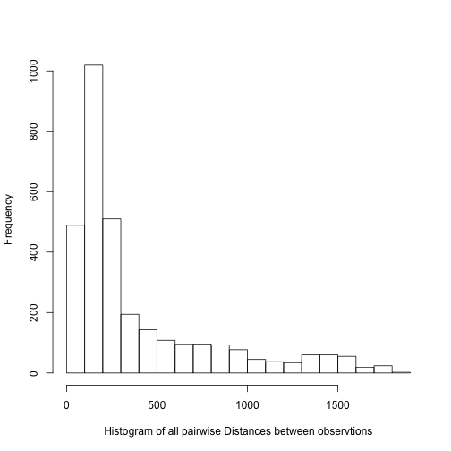

> Visualization is very important for data analytics, as it can provide a first understanding of the data.

#### Step 6. Select the clustering method to use and decide how many clusters to have

There are many statistical methods for clustering and segmentation. In practice one may use various approaches and then eventually select the solution that is statistically robust (see last step below), interpretable, and actionable - among other criteria.

In this note we will use two widely used methods: the **Kmeans Clustering Method**, and the **Hierarchical Clustering Method**. Like all clustering methods, these two also require that we have decided how to measure the distance/similarity between our observations. Explaining how these methods work is beyond our scope. The only difference to highlight is that Kmeans requires the user to define how many segments to create, while Hierarchical Clustering does not.

Let's fist use the **Hierarchial Clustering** method, as we do not know for now how many segments there are in our data. Hierarchical clustering is a method that also helps us visualise how the data may be clustering together. It generates a plot called the **Dendrogram** which is often helpful for visualization - but should be used with care. For example, in this case the dendrogram, using the euclidean distance metric from the earlier steps and the ward hierarchical clustering option (see below as well as help(hclust) in R for more information), is as follows:

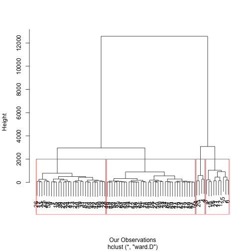

Note that we can draw as many clusters are we choose (e.g. in this case we chose 4 clusters) around the branches of the Dendrogram.

The Dendrogram indicates how this clustering method works: observations are “grouped together”,starting from pairs of individual observations which are the closest to each other, and merging smaller groups into larger ones depending on which groups are closest to each other. Eventually all our data are merged into one segment. The heigths of the branches of the tree indicate how different the clusters merged at that level of the tree are. Longer lines indicate that the clusters below are very different. As expected, the heights of the tree branches increase as we traverse the tree from the end leaves to the tree root: the method merges data points/groups from the closest ones to the furthest ones.

Dendrograms are a helpful visualization tool for segmentation, even if the number of observations is very large - the tree typically grows logarithmically with the number of data. However, they can be very misleading. Notice that once two data points are merged into the same segment they remain in the same segment throughout the tree. This “rigidity” of the Hierarchical Clustering method may lead to segmentations which are suboptimal in many ways. However, the dendrograms are useful in practice to help us get some understanding of the data, including the potential number of segments we have in the data. Moreover, there are various ways to construct the dendrograms, not only depending on the distance metric we defined in the earlier steps above, but also depending on how the data are aggregated into clusters (see helt(hclust) in R, for example, which provides the following options for the way the tree is constructed: “ward”, “single”, “complete”, “average”, “mcquitty”, “median” or “centroid”).

We can also plot the “distances” traveled before we need to merge any of the lower and smaller in size clusters into larger ones - the heights of the tree branches that link the clusters as we traverse the tree from its leaves to its root. If we have n observations, this plot has n-1 numbers.

As a rule of thumb, one can select the number of clusters as the “elbow” of this plot: this is the place in the tree where, if we traverse the tree from the leaves to its root, we need to make the “longest jump” before we merge further the segments at that tree level. Of course the actual number of segments can be very different from what this rule of thumb may indicate: in practice we explore different numbers of segments, possibly starting with what a hierarchical clustering dendrogram may indicate, and eventually we select the final segmentation solution using both statistical and qualitative criteria, as discussed below.

> Selecting the number of clusters requires a combination of statistical reasoning, judgment, interpretability of the clusters, actionable value of the clusters found, and many other quantitative and qualitative criteria. In practice different numbers of segments should be explored, and the final choice should be made based on both statistical and qualitative criteria.

**Using Kmean Clustering**

As always, much like Hierarchical Clustering can be performed using various distance metrics, so can Kmeans. Moreover, there are variations of Kmeans (e.g. “Hartigan-Wong”, “Lloyd”, or “MacQueen” - see help(kmeans) in R) one can explore, which are beyond the scope of this note. **Note:** K-means does not necessarily lead to the same solution every time you run it.

Note that the observations do not need to be in the same clusters as we use different methods, neither do the segment profiles that we will find next. However, a characteristic of **statistically robust segmentation** is that our observations are grouped in similar segments independent of the approach we use. Moreover, the profiles of the segments should not vary much when we use different approaches or variations of the data. We will examine this issue in the last step, after we first discuss how to profile segments.

> The segments found should be relatively robust to changes in the clustering methodology and data subsets used. Most of the observations should belong in the same clusters independent of how the clusters are found. Large changes may indicate that our segmentation is not valid. Moreover, the profiles of the clusters found using different approaches should be as consistent across different approaches as possible. Judging the quality of segmentation is a matter of both robustness of the statistical characteristics of the segments (e.g. changes from different methods and data used) as well as a matter of many qualitative criteria: interpretability, actionability, stability over time, etc.

#### Step 7. Profile and interpret the clusters

Having decided (for now) how many clusters to use, we would like to get a better understanding of who the customers in those clusters are and interpret the segments.

> Data analytics is used to eventually make decisions, and that is feasible only when we are comfortable (enough) with our understanding of the analytics results, including our ability to clearly interpret them.

To this purpose, one needs to spend time visualizing and understanding the data within each of the selected segments. For example, one can see how the summary statistics (e.g. averages, standard deviations, etc) of the **profiling attributes** differ across the segments.

We can also “visualize” the segments using **snake plots** for each cluster. For example, we can plot the means of the profiling variables for each of our clusters to better visualize differences between segments. For better visualization we plot the standardized profiling variables.

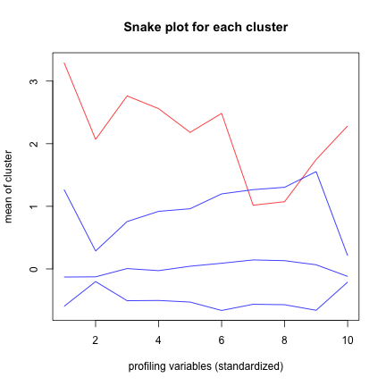

Can we see differences between the segments? Do the segments differ in terms of their average household income and in terms of how often they visit the mall? What else can we say about these segments?

We can also compare the averages of the profiling variables of each segment relative to the average of the variables across the whole population. This can also help us better understand whether there are indeed clusters in our data (e.g. if all segments are much like the overall population, there may be no segments). For example, we can measure the ratios of the average for each cluster to the average of the population (e.g. avg(cluster)/avg(population)) and explore a matrix as the following one:

[output not shown]

**The further a ratio is from 1, the more important that attribute is for a segment relative to the total population.**

Both the snake plot as well as this matrix of relative values of the profiling attributes for each cluster are some of the many ways to visualize our segments and interpret them.

#### Step 8. Assess the robustness of our clusters

The segmentation process outlined so far can be followed with many different approaches, for example:

- using different subsets of the original data
- using variations of the original segmentation attributes
- using different distance metrics
- using different segmentation methods
- using different numbers of clusters

> Much like any data analysis, segmentation is an iterative process with many variations of data, methods, number of clusters, and profiles generated until a satysfying solution is reached.

Clearly exploring all variations is beyond the scope of this note. We discuss, however, an example of how to test the **statistical robustness** and **stability of interpretation** of the clusters found using two different approaches: Kmeans and Hierarchical Clustering, as outlined above.

Two basic tests to perform are:

1. How much overlap is there between the clusters found using different approaches? Specifically, for what percentage of our observations the clusters they belong to are the same across different clustering solutions?
2. How similar are the profiles of the segments found? Specifically, how similar are the averages of the profiling attributes of the clusters found using different approaches?

As we can have the cluster memberships of our observations for all clustering methods, we can measure both the total percentage of observations that remain in the same cluster, as well as this percentage for each cluster separately. For example, for the two 4-segments solutions found above (one using Kmeans and the other using Hierarchical Clustering), these percentages are as follows:

The percentage of observations belonging to the same segment is 20 %.

[output not shown]

Clearly using different numbers of clusters may lead to different percentages of overlap (try for example using 2 clusters): the robustness of our solution may also indicate how many clusters there are in our data - **if any**. However, in general there is no “correct percentage of overlap”, as this depends on how difficult clustering may be (e.g. consider the case where one clusters time series of asset prices): the robustness of our solution is often “relative to other solutions”. Moreover:

> Sound segmentation requires eventually robustness of our decisions across many “good” clustering approaches used.

Only after a number of such robustness checks, profilings, and interpretations, we can end with our final segmentation. During the segmentation analysis we may need to repeat multiple times the process outlined in this note, with many variations of the choices we make at each step of the process, before reaching a final solution (if there are indeed segments in our data) - which of course can be revisited at any point in the future.

> Data Analytics is an iterative process, therefore we may need to return to our original raw data at any point and select new raw attibutes as well as new clusters.

FINAL REPORT STARTS HERE

# Classification Methods

**T. Evgeniou, INSEAD**

## What is this for?

A bank is interested in knowing which customers are likely to default on loan payments. The bank is also interested in knowing what characteristics of customers may explain their loan payment behavior. An advertiser is interested in choosing the set of customers or prospects who are most likely to respond to a direct mail campaign. The advertiser is also interested in knowing what characteristics of consumers are most likely to explain responsiveness to the campaign. A procurement manager is interested in knowing which orders will most likely be delayed, based on recent behavior of the suppliers. An investor is interested in knowing which assets are most likely to increase in value.

Classification (or categorization) techniques are useful to help answer such questions. They help predict the group membership (or class - hence called **classification techniques**) of individuals (data), for **predefined group memberships** (e.g. “success” vs “failure” for **binary** classification, the focus of this note), and also to describe which characteristics of individuals can predict their group membership. Examples of group memberships/classes could be: (1) loyal customers versus customers who will churn; (2) high price sensitive versus low price sensitive customers; (3) satisfied versus dissatisfied customers; (4) purchasers versus non-purchasers; (5) assets that increase in value versus not; (6) products that may be good recommendations to a customer versus not, etc. Characteristics that are useful in classifying individuals/data into predefined groups/classes could include for example (1) demographics; (2) psychographics; (3) past behavior; (4) attitudes towards specific products, (5) social network data, etc.

There are many techniques for solving classification problems: classification trees, logistic regression, discriminant analysis, neural networks, boosted trees, random forests, deep learning methods (an area Facebook [(e.g. see recent academic conference)](https://sites.google.com/site/deeplearningworkshopnips2013/schedule) has [invested in](http://www.wired.com/wiredenterprise/2013/12/facebook-yann-lecun-qa/)) nearest neighbors, support vector machines, etc, (e.g. see the R package “e1071” for more example methods). In this report, for simplicity we focus on the first two, although one can always use some of the other methods instead of the ones discussed here. The focus of this note is not do explain any specific (“black box, math”) classification method, but to describe a process for classification independent of the method used (e.g. independent of the method selected in one of the steps in the process outlined below).

An important question when using classification methods is to assess the relative performance of all available methods/models i.e. in order to use the best one according to our criteria. To this purpose there are standard performance **classification assessment metrics**, which we discuss below - this is a key focus of this note.

## Classification using an Example

### The “Business Decision”

A boating company had become a victim of the crisis in the boating industry. The business problem of the “Boat” case study, although hypothetical, depicts very well the sort of business problems faced by many real companies in an increasingly data-intensive business environment. The management team was now exploring various growth options. Expanding further in some markets, in particular North America, was no longer something to consider for the distant future. It was becoming an immediate necessity.

The team believed that in order to develop a strategy for North America, they needed a better understanding of their current and potential customers in that market. They believed that they had to build more targeted boats for their most important segments there. To that purpose, the boating company had commissioned a project for that market. Being a data-friendly company, the decision was made to develop an understanding of their customers in a data-driven way.

The company would like to understand who would be the most likely customers to purchase a boat in the future or to recommend their brand, as well as what would be the **key purchase drivers** that affect people's decision to purchase or recommend.

### The Data

After analyzing the survey data (using for example factor and cluster analysis), the company managers decided to only focus on a few purchase drivers which they thought were the most important ones. They decided to perform the classification and purchase drivers analysis using only the responses to the following questions:

1 “Q16_1_Is a brand that has been around for a long time”  
2 “Q16_2_Has best in class customer service”  
3 “Q16_3_Has a strong dealer network”  
4 “Q16_4_Is a leader in cutting edge technology”  
5 “Q16_5_Is a leader in safety”  
6 “Q16_6_Is known for its innovative products”  
7 “Q16_7_Is a brand for people who are serious about boating”  
8 “Q16_8_Is a good brand for people that are new to boating”  
9 “Q16_9_Is a brand I see in the water all the time”  
10 “Q16_10_Offers boats that provide a fast and powerful boating experience”  
11 “Q16_11_Offers the best boats for socializing”  
12 “Q16_12_Offers the best boats for water sports e g tubing ski wakeboard ” 13 “Q16_13_Offers boats with superior interior style”  
14 “Q16_14_Offers boats with superior exterior style”  
15 “Q16_15_Offers boats that stand out from the crowd”  
16 “Q16_16_Offers boats that look cool”  
17 “Q16_17_Offers boats that can handle rough weather or choppy water”  
18 “Q16_18_Offers boats that can handle frequent and heavy usage”  
19 “Q16_19_Offers a wide breadth of product offerings and accessories”  
20 “Q16_20_Offers boats that I can move around safely”  
21 “Q16_21_Offers boats that are easy to maintain and or repair”  
22 “Q16_22_Offers boats that are easy to use”  
23 “Q16_23_Offers boats that are easy to clean up”  
24 “Q16_24_Has low prices”  
25 “Q16_25_Is a brand that gives me peace of mind”  
26 “Q16_26_Makes me feel I made a smart decision”  
27 “Q16_27_Is a brand that impresses others”

We will see some descriptive statistics of the data later, when we get into the statistical analysis.

### A Process for Classification

> It is important to remember that Data Analytics Projects require a delicate balance between experimentation, intuition, but also following (once a while) a process to avoid getting fooled by randomness in data and finding “results and patterns” that are mainly driven by our own biases and not by the facts/data themselves.

There is *not a single best* process for classification. However, we have to start somewhere, so we will use the following process:

#### Classification in 6 steps

1. Create an estimation sample and two validation samples by splitting the data into three groups. Steps 2-5 below will then be performed only on the estimation and the first validation data. You should only do step 6 once on the second validation data, also called **test data**, and report/use the performance on that (second validation) data only to make final business decisions.
2. Set up the dependent variable (as a categorical 0-1 variable; multi-class classification is also feasible, and similar, but we do not explore it in this note).
3. Make a preliminary assessment of the relative importance of the explanatory variables using visualization tools and simple descriptive statistics.
4. Estimate the classification model using the estimation data, and interpret the results.
5. Assess the accuracy of classification in the first validation sample, possibly repeating steps 2-5 a few times in different ways to increase performance.
6. Finally, assess the accuracy of classification in the second validation sample. You should eventually use/report all relevant performance measures/plots on this second validation sample only.

Let's follow these steps.

#### Step 1: Splitting the data into estimation and validation samples

It is very important that you finally measure and report (or expect to see from the data scientists working on the project) the performance of the models on **data that have not been used at all during the analysis, called “out-of-sample” or test data** (steps 2-5 above). The idea is that in practice we want our models to be used for predicting the class of observations/data we have not seen yet (e.g. “the future data”): although the performance of a classification method may be high in the data used to estimate the model parameters, it may be significantly poorer on data not used for parameter estimation, such as the **out-of-sample** (future) data in practice. The second validation data mimic such out-of-sample data, and the performance on this validation set is a better approximation of the performance one should expect in practice from the selected classification method. This is why we split the data into an estimation sample and two validation samples - using some kind of randomized splitting technique. The estimation data and the first validation data are used during steps 2-5 (with a few iterations of these steps), while the second validation data is only used once at the very end before making final business decisions based on the analysis. The split can be, for example, 80% estimation, 10% validation, and 10% test data, depending on the number of observations - for example, when there is a lot of data, you may only keep a few hundreds of them for the validation and test sets, and use the rest for estimation.

While setting up the estimation and validation samples, you should also check that the same proportion of data from each class, i.e. people who plan to purchase a boat versus not, are maintained in each sample, i.e., you should maintain the same balance of the dependent variable categories as in the overall dataset.

For simplicy, in this note we will not iterate steps 2-5. Again, this should **not** be done in practice, as we should usually iterate steps 2-5 a number of times using the first validation sample each time, and make our final assessment of the classification model using the test sample only once (ideally).

We typically call the three data samples as **estimation_data** (e.g. 35% of the data in our case), **validation_data** (e.g. the 30% of the data) and **test_data** (e.g. the remaining 35% of the data).

In our case we use for example 28 observations in the estimation data, 24 in the validation data, and 28 in the test data.

#### Step 2: Setting up the dependent variable

First, make sure the dependent variable is set up as a categorical 0-1 variable. In this illustrative example, the “intent to recommend” and “intent to purchase” are 0-1 variables: we will use the later as our dependent variable but a similar analysis could be done for the former.

The data however may not be always readily available with a categorical dependent variable. Suppose a retail store wants to understand what discriminates consumers who are loyal versus those who are not. If they have data on the amount that customers spend in their store or the frequency of their purchases, they can create a categorical variable (“loyal vs not-loyal”) by using a definition such as: “A loyal customer is one who spends more than X amount at the store and makes at least Y purchases a year”. They can then code these loyal customers as “1” and the others as “0”. They can choose the thresholds X and Y as they wish: a definition/decision that may have a big impact in the overall analysis. This decision can be the most crucial one of the whole data analysis: a wrong choice at this step may lead both to poor performance later as well as to no valuable insights. One should revisit the choice made at this step several times, iterating steps 2-3 and 2-5.

> Carefully deciding what the dependent 0/1 variable is can be the most critical choice of a classification analysis. This decision typically depends on contextual knowledge and needs to be revisited multiple times throughout a data analytics project.

In our data the number of 0/1's in our estimation sample is as follows:

Number of Observations per class in the Estimation Sample

|  | Class 1 | Class 0 |
| --- | --- | --- |
| # of Observations | 10 | 18 |

while in the validation sample they are:

Number of Observations per class in the Validation Sample

|  | Class 1 | Class 0 |
| --- | --- | --- |
| # of Observations | 2 | 22 |

#### Step 3: Make a preliminary assessment of the relative importance of the explanatory variables using visualization tools and simple descriptive statistics.

Notice however that:

> Even though each independent variable may not differ across classes, classification may still be feasible: a (linear or nonlinear) combination of independent variables may still be discriminatory.

A simple visualization tool to assess the discriminatory power of the independent variables are the **box plots**. These visually indicate simple summary statistics of an independent variable (e.g. mean, median, top and bottom quantiles, min, max, etc). For example consider the box plots for our data for the class 0 (top) and class 1 (bottom):

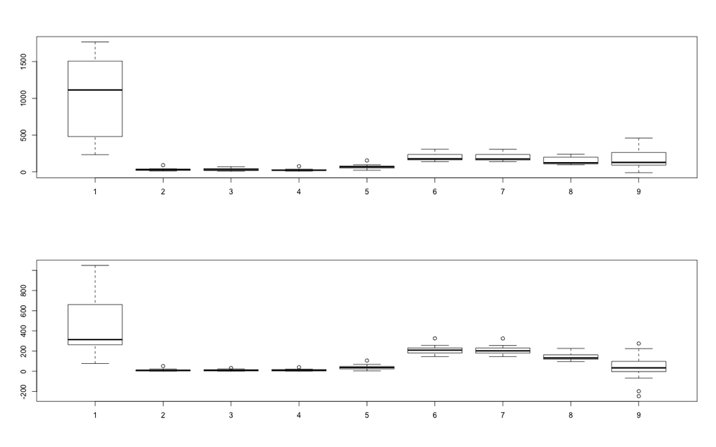

Can you see which variables appear to be the most discrimatory ones?

#### Step 4: Estimate the classification model using the estimation data, and interpret the results.

Once we decide which dependent and independent variables to use (which can be revisited in later iterations), one can use a number of classification methods to develop a model that discriminates the different classes.

> Some of the widely used classification methods are: classification and regression trees, boosted trees, support vector machines, neural networks, nearest neighbors, logistic regression, lasso, random forests, deep learning methods, etc.

In this note we will consider for simplicity only two classification methods: **logistic regression** and **classification and regression trees (CART)**. However, replacing them with other methods is relatively simple (although some knowledge of how these methods work is often necessary - see the R help command for the methods if needed). Understanding how these methods work is beyond the scope of this note - there are many references available online for all these classification methods.

> One of the biggest risks when developing classification models is overfitting: while it is always trivial to develop a model (e.g. a tree) that classifies any (estimation) dataset with no misclassification error at all, there is no guarantee that the quality of a classifier in out-of-sample data (e.g. in the validation data) will be close to that in the estimation data. Striking the right balance between “over-fitting” and “under-fitting” is one of the most important aspects in data analytics. While there are a number of statistical techniques to help us find this balance - including the use of validation data - it is largely a combination of good statistical analysis with qualitative criteria (e.g. regarding the interpretability or simplicity of the estimated models) that leads to classification models which can work well in practice.

Running a basic CART model with complexity control cp=0.01, leads to the following tree (**NOTE**: for better readability of the tree figures below, we will rename the independent variables as IV1 to IV9 when using CART):

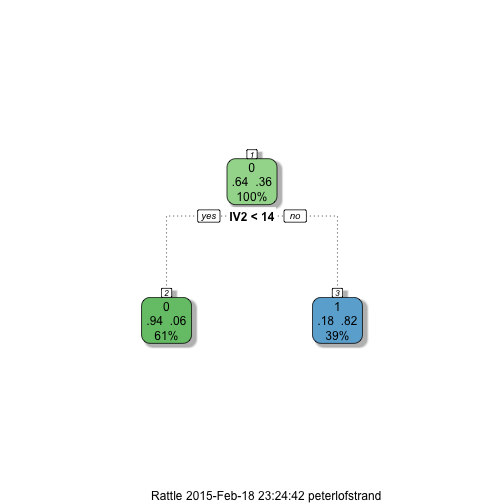

The leaves of the tree indicate the number of estimation data observations that belong to each class which “reach that leaf” as well as the pecentage of all data points that reach the leaf. A perfect classification would only have data from one class in each of the tree leaves. However, such a perfect classification of the estimation data would most likely not be able to classify well out-of-sample data due to over-fitting of the estimation data.

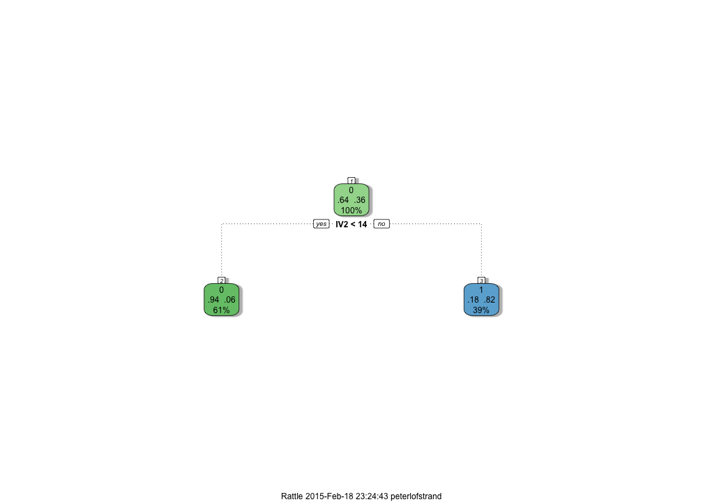

In practice we need to select the **probability threshold** above which we consider an observation as “class 1”: this is an important choice that we will discuss below. First we discuss another method widely used, namely logistic regression.

**Logistic Regression** is a method similar to linear regression except that the dependent variable can be discrete (e.g. 0 or 1). **Linear** logistic regression estimates the coefficients of a linear model using the selected independent variables while optimizing a classification criterion. For example, this is the logistic regression parameters for our data:

Logistic Regression: Estimated Coefficients

|  | Estimate | Std. Error | z value | Pr(>\|z\|) |
| --- | --- | --- | --- | --- |
| (Intercept) | -5.1 | 6.4 | -0.8 | 0.4 |
| point | 0.0 | 0.0 | 1.0 | 0.3 |
| victories | 0.1 | 0.2 | 0.4 | 0.7 |
| poles | 0.1 | 0.1 | 0.9 | 0.3 |
| Fastest.lap | 0.1 | 0.2 | 0.8 | 0.4 |
| podium | -0.1 | 0.1 | -0.8 | 0.4 |
| entries | 0.0 | 0.3 | 0.1 | 0.9 |
| qualification | -0.0 | 0.3 | -0.0 | 1.0 |
| classified | -0.0 | 0.1 | -0.0 | 1.0 |
| CP….. | 0.0 | 0.0 | 0.6 | 0.5 |

The default decision is to classify each observation in the group with the highest probability - but one can change this choice, as we discuss below.

Selecting the best subset of independent variables for logistic regression, a special case of the general problem of **feature selection**, is an iterative process where both the significance of the regression coefficients as well as the performance of the estimated logistic regression model on the first validation data are used as guidance. A number of variations are tested in practice, each leading to different performances, which we discuss next.

In our case, we can see the relative importance of the independent variables using the “variable.importance” of the CART trees (see help(rpart.object) in R) or the z-scores from the output of logistic regression. For easier visualization, we scale all values between -1 and 1 (the scaling is done for each method separately - note that CART does not provide the sign of the “coefficients”). From this table we can see the **key drivers** of the classification according to each of the methods we used here.

[output not shown]

In general it is not necessary for all methods to agree on the most important drivers: when there is “major” disagreement, particularly among models that have satisfactory performance as discussed next, we may need to reconsider the overall analysis, including the objective of the analysis as well as the data used, as the results may not be robust. **As always, interpreting and using the results of data analytics requires a balance between quantitative and qualitative analysis.**

#### Step 5: Assess the accuracy of classification in the first validation sample

Using the predicted class probabilities of the validation data, as outlined above, we can generate four basic measures of classification performance. Before discussing them, note that given the probability an observation belongs to a class, **a reasonable class prediction choice is to predict the class that has the highest probability**. However, this does not need to be the only choice in practice.

> Selecting the probability threshold based on which we predict the class of an observation is a decision the user needs to make. While in some cases a reasonable probability threshold is 50%, in other cases it may be 99.9% or 0.01%. Can you think of such cases?

For different choices of the probability threshold, one can measure a number of classification performance metrics, which are outlined next.

### 1. **Hit ratio**

This is simply the percentage of the observations that have been correctly classified (the predicted is the same as the actual class). We can just count the number of the (first) validation data correctly classified and divide this number with the total number of the (fist) validation data, using the two CART and the logistic regression above. These are as follows for the probability threshold 50% for the validation data:

Validation Data Hit Ratios for different classifiers tested

|  | Hit Ratio |
| --- | --- |
| First CART | 91.7 |
| Second CART | 91.7 |
| Logistic Regression | 91.7 |

while for the estimation data the hit rates are:

Estimation Data Hit Ratios for different classifiers tested

|  | Hit Ratio |
| --- | --- |
| First CART | 89.3 |
| Second CART | 89.3 |
| Logistic Regression | 82.1 |

**Why are the performances on the estimation and validation data different? How different can they possibly be? What does this diffference depend on?** Is the Validation Data Hit Rate satisfactory? Which classifier should we use? What should be the benchmark against which to compare the hit rate?

A simple benchmark to compare the performance of a classification model against is the **Maximum Chance Criterion**. This measures the proportion of the class with the largest size. For our validation data the largest group is people who do not intent do purchase a boat: 22 out of 24 people). Clearly without doing any discriminant analysis, if we classified all individuals into the largest group, we could get a hit-rate of 91.67% - without doing any work. One should have a hit rate of at least as much as the the Maximum Chance Criterion rate, although as we discuss next there are more performance criteria to consider.

### 2. **Confusion matrix**

The confusion matrix shows for each class the number (or percentage) of the data that are correctly classified for that class. For example for the method above with the highest hit rate in the validation data (among logistic regression and the 2 CART models), the confusion matrix for the validation data is:

Confusion Matrix for Validation data

[output not shown]

Note that the percentages add up to 100% for each row: can you see why? Moreover, a “good” confusion matrix should have large diagonal values and small off-diagonal oens: you see why?

### 3. **ROC curve**

Remember that each observation is classified by our model according to the probabilities Pr(0) and Pr(1) and a chosen probability threshold. Typically we set the probability threshold to 0.5 - so that observations for which Pr(1) > 0.5 are classified as 1's. However, we can vary this threshold, for example if we are interested in correctly predicting all 1's but do not mind missing some 0's (and vice-versa) - can you think of such a scenario?

When we change the probability threshold we get different values of hit rate, false positive and false negative rates, or any other performance metric. We can plot for example how the false positive versus true posititive rates change as we alter the probability threshold, and generate the so called ROC curve.

which, if we plot all in the same graph for comparison, are (black: CART 1; red: CART 2; blue: logistic regression):

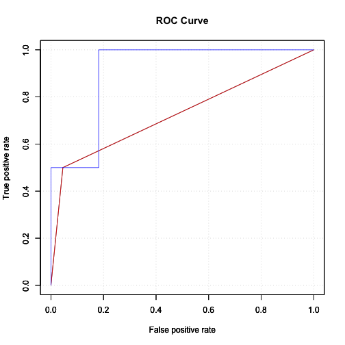

How should a good ROC curve look like? A rule of thumb in assessing ROC curves is that the “higher” the curve, hence the larger the area under the curve, the better. You may also select one point on the ROC curve (the “best one” for our purpose) and use that false positive/false negative performances (and corresponding threshold for P(0)) to assess your model. **Which point on the ROC should we select?**

### 4. **Lift curve**

By changing the probability threshold, we can also generate the so called lift curve, which is useful for certain applications e.g. in marketing or credit risk. For example, consider the case of capturing fraud by examining only a few transactions instead of every single one of them. In this case we may want to examine as few transactions as possible and capture the maximum number of frauds possible. We can measure the percentage of all frauds we capture if we only examine, say, x% of cases (the top x% in terms of Probability(fraud)). If we plot these points [percentage of class 1 captured vs percentage of all data examined] while we change the threshold, we get a curve that is called the **lift curve**.

How should a good Lift Curve look like? Notice that if we were to randomly examine transactions, **the “random prediction” lift curve would be a 45 degrees straight diagonal line** (why?)! So the further **above** this 45 degrees line our Lift curve is, the better the “lift”. Moreover, much like for the ROC curve, one can select the probability threshold appropriately so that any point of the lift curve is selected. **Which point on the lift curve should we select in practice?**

### 5. **Profit Curve**

Finally, we can generate the so called profit curve, which we often use to make our final decisions. The intuition is as follows. Consider a direct marketing campaign, and suppose it costs $ 1 to send an advertisement, and the expected profit from a person who responds positively is $45. Suppose you have a database of 1 million people to whom you could potentially send the ads. What fraction of the 1 million people should you send ads (typical response rates are 0.05%)? To answer this type of questions we need to create the profit curve, which is generated by changing again the probability threshold for classifying observations: for each threshold value we can simply measure the total **Expected Profit** (or loss) we would generate. This is simply equal to:

> Total Expected Profit = (% of 1’s correctly predicted)x(value of capturing a 1) + (% of 0’s correctly predicted)x(value of capturing a 0) + (% of 1’s incorrectly predicted as 0)x(cost of missing a 1) + (% of 0’s incorrectly predicted as 1)x(cost of missing a 0) Calculating the expected profit requires we have an estimate of the 4 costs/values: value of capturing a 1 or a 0, and cost of misclassifying a 1 into a 0 or vice versa.

Assumed Profits and Costs

|  | Predict 1 | Predict 0 |
| --- | --- | --- |
| Actual 1 | 100.0 | -75.0 |
| Actual 0 | -50.0 | 0.0 |

We can then select the threshold that corresponds to the maximum expected profit (or minimum loss, if necessary).

Notice that for us to maximize expected profit we need to have the cost/profit for each of the 4 cases! This can be difficult to assess, hence typically some sensitivity analysis to our assumptions about the cost/profit needs to be done: for example, we can generate different profit curves (i.e. worst case, best case, average case scenarios) and see how much the best profit we get varies, and most important **how our selection of the classification model and of the probability threshold vary** as these are what we need to eventually decide.

#### Step 6: Finally, assess the accuracy of classification in the test data.

Having iterated steps 2-5 until we are satisfyed with the performance of our selected model on the validation data, in this step the performance analysis outlined in step 5 needs to be done with the test sample. This is the performance that “best mimics” what one should expect in practice upon deployment of the classification solution, **assuming (as always) that the data used for this performance analysis are representative of the situation in which the solution will be deployed.**

**Will the performance in the test data be similar to the performance in the validation data above? More important: should we expect the performance of our classification model to be close to that in our test data when we deploy the model in practice? Why or why not? What should we do if they are different?**

The Confusion Matrix for the model with the best validation data hit ratio above:

Confusion Matrix for test data

|  | Predicted 1 | Predicted 0 |
| --- | --- | --- |
| Actual 1 | 0.0 | 100.0 |
| Actual 0 | 96.0 | 4.0 |

ROC curves for the test data

which, if we plot all in the same graph for comparison, are (black: CART 1; red: CART 2; blue: logistic regression):

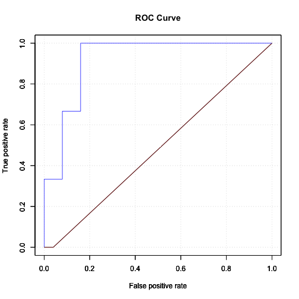

## What if we consider a segment-specific analysis?

Often our data (e.g. people) belong to different segments. In such cases, if we perform the classification analysis using all segments together we may not be able to find good quality models or strong classification drivers.

> When we believe our observations belong in different segments, we should perform the classification and drivers analysis for each segment separately.

In this case, let's assume we found some customer segments based on earlier analysis. We consider two segmentation solutions:

Let's see first how many observations we have in each segment:

Number of Observations per segment in the Dataset

|  | Segment 1 | Segment 2 | Segment 3 | Segment 4 |
| --- | --- | --- | --- | --- |
| Number of Obs. | 4 | 10 | 29 | 37 |

[output not shown]

[output not shown]

Let's see first how many observations we have in each segment:

Number of Observations per segment in the Dataset

|  | Segment 1 | Segment 2 | Segment 3 | Segment 4 |
| --- | --- | --- | --- | --- |
| Number of Obs. | 4 | 10 | 29 | 37 |

[output not shown]

[output not shown]

**Does segment specific analysis help for our business decisions? Which solution should we use? Should we explore a different solution? Should we re-start from data collection, factor analysis, segmentation, or classification and drivers' analysis? How can we use the final results?**

Of course, as always, remember that

> Data Analytics is an iterative process, therefore we may need to return to our original raw data at any point and select new raw attributes as well as a different classification tool and model.

**Till then…**